# SL_Project_Part_A

```python
import numpy as np
import pandas as pd
import seaborn as sns
import matplotlib as plt
import sklearn
```

1.Data Understanding A.Read all the 3 CSV files as DataFrame and store them into 3 separate variables

```python
data_1 = pd.read_csv('Part1+-+Normal.csv')
data_1.head()
```

|  | P_incidence | P_tilt | L_angle | S_slope | P_radius | S_Degree | Class |
| --- | --- | --- | --- | --- | --- | --- | --- |
| 0 | 38.505273 | 16.964297 | 35.112814 | 21.540976 | 127.632875 | 7.986683 | Normal |
| 1 | 54.920858 | 18.968430 | 51.601455 | 35.952428 | 125.846646 | 2.001642 | Normal |
| 2 | 44.362490 | 8.945435 | 46.902096 | 35.417055 | 129.220682 | 4.994195 | Normal |
| 3 | 48.318931 | 17.452121 | 48.000000 | 30.866809 | 128.980308 | -0.910941 | Normal |
| 4 | 45.701789 | 10.659859 | 42.577846 | 35.041929 | 130.178314 | -3.388910 | Normal |

```python
data_2 = pd.read_csv('Part1+-+Type_H.csv')
data_2.head()
```

|  | P_incidence | P_tilt | L_angle | S_slope | P_radius | S_Degree | Class |
| --- | --- | --- | --- | --- | --- | --- | --- |
| 0 | 63.027817 | 22.552586 | 39.609117 | 40.475232 | 98.672917 | -0.254400 | Type_H |
| 1 | 39.056951 | 10.060991 | 25.015378 | 28.995960 | 114.405425 | 4.564259 | Type_H |
| 2 | 68.832021 | 22.218482 | 50.092194 | 46.613539 | 105.985135 | -3.530317 | Type_H |
| 3 | 69.297008 | 24.652878 | 44.311238 | 44.644130 | 101.868495 | 11.211523 | Type_H |
| 4 | 49.712859 | 9.652075 | 28.317406 | 40.060784 | 108.168725 | 7.918501 | Type_H |

```python
data_3=pd.read_csv('Part1+-+Type_S.csv')
data_3.head()
```

|  | P_incidence | P_tilt | L_angle | S_slope | P_radius | S_Degree | Class |
| --- | --- | --- | --- | --- | --- | --- | --- |
| 0 | 74.377678 | 32.053104 | 78.772013 | 42.324573 | 143.560690 | 56.125906 | Type_S |
| 1 | 89.680567 | 32.704435 | 83.130732 | 56.976132 | 129.955476 | 92.027277 | Type_S |
| 2 | 44.529051 | 9.433234 | 52.000000 | 35.095817 | 134.711772 | 29.106575 | Type_S |
| 3 | 77.690577 | 21.380645 | 64.429442 | 56.309932 | 114.818751 | 26.931841 | Type_S |
| 4 | 76.147212 | 21.936186 | 82.961502 | 54.211027 | 123.932010 | 10.431972 | Type_S |

B.Print Shape and columns of all the 3 DataFrames.

```python
data_1.shape
```

```
(100, 7)
```

```python
data_2.shape
```

```
(60, 7)
```

```python
data_3.shape
```

```
(150, 7)
```

C. Compare Column names of all the 3 DataFrames and clearly write observations

```python
data_1.columns
```

```
Index(['P_incidence', 'P_tilt', 'L_angle', 'S_slope', 'P_radius', 'S_Degree',
       'Class'],
      dtype='object')
```

```python
data_2.columns
```

```
Index(['P_incidence', 'P_tilt', 'L_angle', 'S_slope', 'P_radius', 'S_Degree',
       'Class'],
      dtype='object')
```

```python
data_3.columns
```

```
Index(['P_incidence', 'P_tilt', 'L_angle', 'S_slope', 'P_radius', 'S_Degree',
       'Class'],
      dtype='object')
```

All indices are same in all three dataframes.

D. Print DataTypes of all the 3 DataFrames

```python
data_1.dtypes
```

```
P_incidence    float64
P_tilt         float64
L_angle        float64
S_slope        float64
P_radius       float64
S_Degree       float64
Class           object
dtype: object
```

```python
data_2.dtypes
```

```
P_incidence    float64
P_tilt         float64
L_angle        float64
S_slope        float64
P_radius       float64
S_Degree       float64
Class           object
dtype: object
```

```python
data_3.dtypes
```

```
P_incidence    float64
P_tilt         float64
L_angle        float64
S_slope        float64
P_radius       float64
S_Degree       float64
Class           object
dtype: object
```

E.Observe and share variation in ‘Class’ feature of all the 3 DaraFrames.

```python
data_1['Class']
```

```
0     Normal
1     Normal
2     Normal
3     Normal
4     Normal
       ...
95    Normal
96    Normal
97    Normal
98    Normal
99    Normal
Name: Class, Length: 100, dtype: object
```

```python
data_2['Class']
```

```
0     Type_H
1     Type_H
2     Type_H
3     Type_H
4     Type_H
5     Type_H
6     Type_H
7     Type_H
8     Type_H
9     Type_H
10    Type_H
11    Type_H
12    Type_H
13    Type_H
14    Type_H
```

[output cut: 46 more lines]

```python
data_3['Class']
```

```
0      Type_S
1      Type_S
2      Type_S
3      Type_S
4      Type_S
        ...
145    Type_S
146    Type_S
147    Type_S
148    Type_S
149    Type_S
Name: Class, Length: 150, dtype: object
```

2.Data Preparation and Exploration

A. Unify all the variations in ‘Class’ feature for all the 3 DataFrames

```python
data_1_uni= data_1.replace({'Class':{"Nrmal":'Normal'}})

data_1_uni.head()
```

|  | P_incidence | P_tilt | L_angle | S_slope | P_radius | S_Degree | Class |
| --- | --- | --- | --- | --- | --- | --- | --- |
| 0 | 38.505273 | 16.964297 | 35.112814 | 21.540976 | 127.632875 | 7.986683 | Normal |
| 1 | 54.920858 | 18.968430 | 51.601455 | 35.952428 | 125.846646 | 2.001642 | Normal |
| 2 | 44.362490 | 8.945435 | 46.902096 | 35.417055 | 129.220682 | 4.994195 | Normal |
| 3 | 48.318931 | 17.452121 | 48.000000 | 30.866809 | 128.980308 | -0.910941 | Normal |
| 4 | 45.701789 | 10.659859 | 42.577846 | 35.041929 | 130.178314 | -3.388910 | Normal |

```python
data_2_uni= data_2.replace({'Class':{"Type_H":'type_h'}})

data_2_uni.head()
```

|  | P_incidence | P_tilt | L_angle | S_slope | P_radius | S_Degree | Class |
| --- | --- | --- | --- | --- | --- | --- | --- |
| 0 | 63.027817 | 22.552586 | 39.609117 | 40.475232 | 98.672917 | -0.254400 | type_h |
| 1 | 39.056951 | 10.060991 | 25.015378 | 28.995960 | 114.405425 | 4.564259 | type_h |
| 2 | 68.832021 | 22.218482 | 50.092194 | 46.613539 | 105.985135 | -3.530317 | type_h |
| 3 | 69.297008 | 24.652878 | 44.311238 | 44.644130 | 101.868495 | 11.211523 | type_h |
| 4 | 49.712859 | 9.652075 | 28.317406 | 40.060784 | 108.168725 | 7.918501 | type_h |

```python
data_3_uni= data_3.replace({'Class':{"Type_S":'type_s' ,'tp_s':'type_s'}})

data_3_uni.head()
```

|  | P_incidence | P_tilt | L_angle | S_slope | P_radius | S_Degree | Class |
| --- | --- | --- | --- | --- | --- | --- | --- |
| 0 | 74.377678 | 32.053104 | 78.772013 | 42.324573 | 143.560690 | 56.125906 | type_s |
| 1 | 89.680567 | 32.704435 | 83.130732 | 56.976132 | 129.955476 | 92.027277 | type_s |
| 2 | 44.529051 | 9.433234 | 52.000000 | 35.095817 | 134.711772 | 29.106575 | type_s |
| 3 | 77.690577 | 21.380645 | 64.429442 | 56.309932 | 114.818751 | 26.931841 | type_s |
| 4 | 76.147212 | 21.936186 | 82.961502 | 54.211027 | 123.932010 | 10.431972 | type_s |

B. Combine all the 3 DataFrames to form a single DataFrame

```python
df_res = data_1_uni.append(data_2_uni,ignore_index = True)

df_final = df_res.append(data_3_uni,ignore_index =True)
df_final.shape
```

```
(310, 7)
```

C. Print 5 random samples of this DataFrame

```python
df_samp = df_final.sample(n=5)
print(df_samp)
```

```
     P_incidence     P_tilt    L_angle    S_slope    P_radius   S_Degree  \
47     50.160078  -2.970024  42.000000  53.130102  131.802491  -8.290203
304    56.535051  14.377189  44.991547  42.157862  101.723334  25.773174
60     51.311771   8.875541  57.000000  42.436230  126.472258  -2.144044
66     51.325464  13.631223  33.258578  37.694240  131.306122   1.788870
219    60.753893  15.753894  43.199158  45.000000  113.053331  31.693548

      Class
47   Normal
304  type_s
60   Normal
66   Normal
219  type_s
```

D. Print Feature-wise percentage of Null values.

```python
null_percent = (df_final.isnull().sum())/len(df_final)
null_percent
```

```
P_incidence    0.0
P_tilt         0.0
L_angle        0.0
S_slope        0.0
P_radius       0.0
S_Degree       0.0
Class          0.0
dtype: float64
```

E. Check 5-point summary of the new DataFrame

```python
df_final.describe()
```

|  | P_incidence | P_tilt | L_angle | S_slope | P_radius | S_Degree |
| --- | --- | --- | --- | --- | --- | --- |
| count | 310.000000 | 310.000000 | 310.000000 | 310.000000 | 310.000000 | 310.000000 |
| mean | 60.496653 | 17.542822 | 51.930930 | 42.953831 | 117.920655 | 26.296694 |
| std | 17.236520 | 10.008330 | 18.554064 | 13.423102 | 13.317377 | 37.559027 |
| min | 26.147921 | -6.554948 | 14.000000 | 13.366931 | 70.082575 | -11.058179 |
| 25% | 46.430294 | 10.667069 | 37.000000 | 33.347122 | 110.709196 | 1.603727 |
| 50% | 58.691038 | 16.357689 | 49.562398 | 42.404912 | 118.268178 | 11.767934 |
| 75% | 72.877696 | 22.120395 | 63.000000 | 52.695888 | 125.467674 | 41.287352 |
| max | 129.834041 | 49.431864 | 125.742385 | 121.429566 | 163.071041 | 418.543082 |

1. Data Analysis

A. Visualize a heatmap to understand correlation between all features

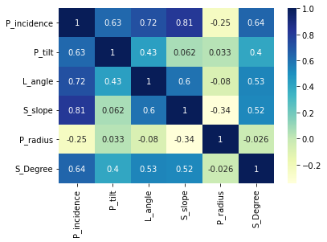

```python
import seaborn as sb
dataplot = sb.heatmap(df_final.corr(), cmap="YlGnBu", annot=True)
```

B. Share insights on correlation A. Features having stronger correlation with correlation value ans: Features having stronger correlation are those with correlation values greater than +0.5 to 1. p_incidence and P_tilt , L_angle and P_incidence S_slope and P_incidence ,S_degree and P_incidence, S_slope and S_degree show stronger correlation.positive values indicates positive correlation.

B. Features having weaker correlation with correlation value

Correlation values less than +0.5 to 0, shows weaker correlation and negative values indicate negative association. Features P_incidence and Pradius show negative association and p tilt shows weaker correlation with S_Degree.Pradius shows negative weak correlation with S_slope. P_radius shows significantly weaker negative relation withthe veature S_Radius.

C. Visualize a pairplot with 3 classes distinguished by colors and share insights

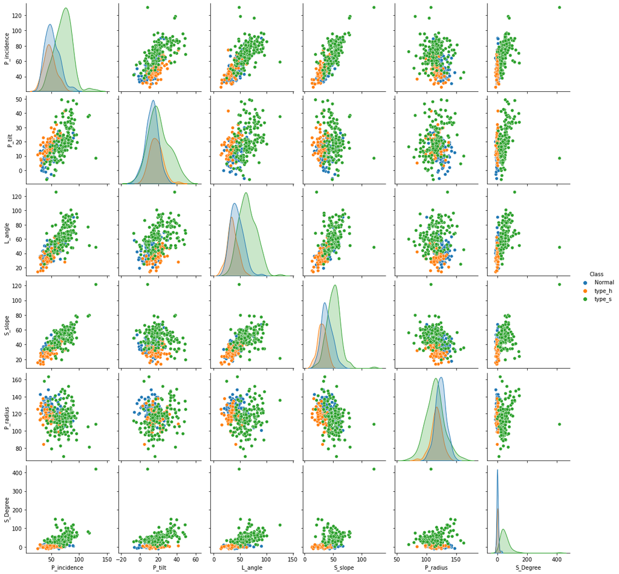

```python
sns.pairplot(df_final,hue='Class')
```

D. Visualize a jointplot for ‘P_incidence’ and ‘S_slope’ and share insights

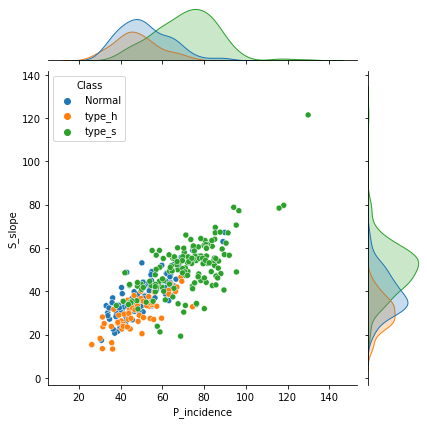

```python
sns.jointplot( x='P_incidence',
    y='S_slope',
    data=df_final,
    kind='scatter',
    hue='Class')
```

Biomechanics attributes 'P_incidence' and 'S_Slope' shows a positive linear relationship from this jointplot. here too we observe that the type s class is predominant over the rest of the two classes.

E. Visualize a boxplot to check distribution of the features and share insights.

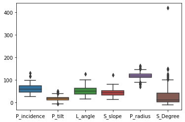

```python
sns.boxplot(data =df_final)
```

```python
df_final.groupby(["Class"]).count()
```

| Class | P_incidence | P_tilt | L_angle | S_slope | P_radius | S_Degree |
| --- | --- | --- | --- | --- | --- | --- |
| Normal | 100 | 100 | 100 | 100 | 100 | 100 |
| type_h | 60 | 60 | 60 | 60 | 60 | 60 |
| type_s | 150 | 150 | 150 | 150 | 150 | 150 |

1. Model Building